# Practical Machine Learning

By Bruno Gomes

Using devices such as Jawbone Up, Nike FuelBand, and Fitbit it is now possible to collect a large amount of data about personal activity relatively inexpensively. These type of devices are part of the quantified self movement – a group of enthusiasts who take measurements about themselves regularly to improve their health, to find patterns in their behavior, or because they are tech geeks. One thing that people regularly do is quantify how much of a particular activity they do, but they rarely quantify how well they do it. In this project, your goal will be to use data from accelerometers on the belt, forearm, arm, and dumbell of 6 participants. They were asked to perform barbell lifts correctly and incorrectly in 5 different ways. More information is available from the website here: http://groupware.les.inf.puc-rio.br/har (see the section on the Weight Lifting Exercise Dataset).

```r
library(ggplot2)
library(caret)
```

```r
library(randomForest)
```

```r
library(dplyr)
```

```r
library(corrplot)
```

```r
library(rpart)
library(rpart.plot)
```

Download the training and test dataset

```r
dstraining <- read.csv("https://raw.githubusercontent.com/brunogomesweb/practice-machine-learning/0e3d96fd120e5d7520f9ebe16c79d2f25cd6a5e7/pml-training.csv", na.strings=c("#DIV/0!"), row.names = 1)

dsteste <- read.csv("https://raw.githubusercontent.com/brunogomesweb/practice-machine-learning/0e3d96fd120e5d7520f9ebe16c79d2f25cd6a5e7/pml-testing.csv", na.strings=c("#DIV/0!"), row.names = 1)
```

We have a total of 19622 training lines and 20 test cases to validate the model

Preprocessing

Removing NA columns

```r
dstraining <- dstraining[, colSums(is.na(dstraining)) == 0]
dsteste <- dsteste[, colSums(is.na(dsteste)) == 0]
```

Removing NA columns

```r
dstraining <- dstraining[, colSums(is.na(dstraining)) == 0]
dsteste <- dsteste[, colSums(is.na(dsteste)) == 0]
```

```r
classe <- dstraining$classe
dstrainingRemove <- grepl("^X|timestamp|window", names(dstraining))
dstraining <- dstraining[, !dstrainingRemove]

dstrainingCleaned <- dstraining[, sapply(dstraining, is.numeric)]
dstrainingCleaned$classe <- classe

dstesteRemove <- grepl("^X|timestamp|window", names(dsteste))
dsteste <- dsteste[, !dstesteRemove]

dstesteCleaned <- dsteste[, sapply(dsteste, is.numeric)]
```

Separation of training and test data

```r
set.seed(0123)
trainset <- createDataPartition(dstrainingCleaned$classe, p = 0.75, list = FALSE)
training <- dstrainingCleaned[trainset, ]
Validation <- dstrainingCleaned[-trainset, ]
```

Using random forest model to automatically select the most important variables using 5-fold cross-validation.

```r
controlRandomf <- trainControl(method="cv", 5)
mdRandomf <- train(classe ~ ., data=training, method="rf", trControl=controlRandomf, ntree=250)
mdRandomf
```

```
## Random Forest
##
## 14718 samples
##    52 predictor
##     5 classes: 'A', 'B', 'C', 'D', 'E'
##
## No pre-processing
## Resampling: Cross-Validated (5 fold)
## Summary of sample sizes: 11774, 11775, 11774, 11775, 11774
## Resampling results across tuning parameters:
##
##   mtry  Accuracy   Kappa
##    2    0.9912350  0.9889126
##   27    0.9917108  0.9895148
##   52    0.9842369  0.9800576
##
## Accuracy was used to select the optimal model using the largest value.
## The final value used for the model was mtry = 27.
```

Estimating model performance with the confusion matrix

```r
predictRandomf <- predict(mdRandomf, Validation)
confusionMatrix(table(Validation$classe, predictRandomf))
```

```
## Confusion Matrix and Statistics
##
##    predictRandomf
##        A    B    C    D    E
##   A 1395    0    0    0    0
##   B    5  942    2    0    0
##   C    0    7  847    1    0
##   D    0    1    5  798    0
##   E    0    0    3    3  895
##
## Overall Statistics
##
##                Accuracy : 0.9945
##                  95% CI : (0.992, 0.9964)
##     No Information Rate : 0.2855
##     P-Value [Acc > NIR] : < 2.2e-16
##
##                   Kappa : 0.993
##
##  Mcnemar's Test P-Value : NA
##
## Statistics by Class:
##
##                      Class: A Class: B Class: C Class: D Class: E
## Sensitivity            0.9964   0.9916   0.9883   0.9950   1.0000
## Specificity            1.0000   0.9982   0.9980   0.9985   0.9985
## Pos Pred Value         1.0000   0.9926   0.9906   0.9925   0.9933
## Neg Pred Value         0.9986   0.9980   0.9975   0.9990   1.0000
## Prevalence             0.2855   0.1937   0.1748   0.1635   0.1825
## Detection Rate         0.2845   0.1921   0.1727   0.1627   0.1825
## Detection Prevalence   0.2845   0.1935   0.1743   0.1639   0.1837
## Balanced Accuracy      0.9982   0.9949   0.9932   0.9968   0.9993
```

Top 20 plot

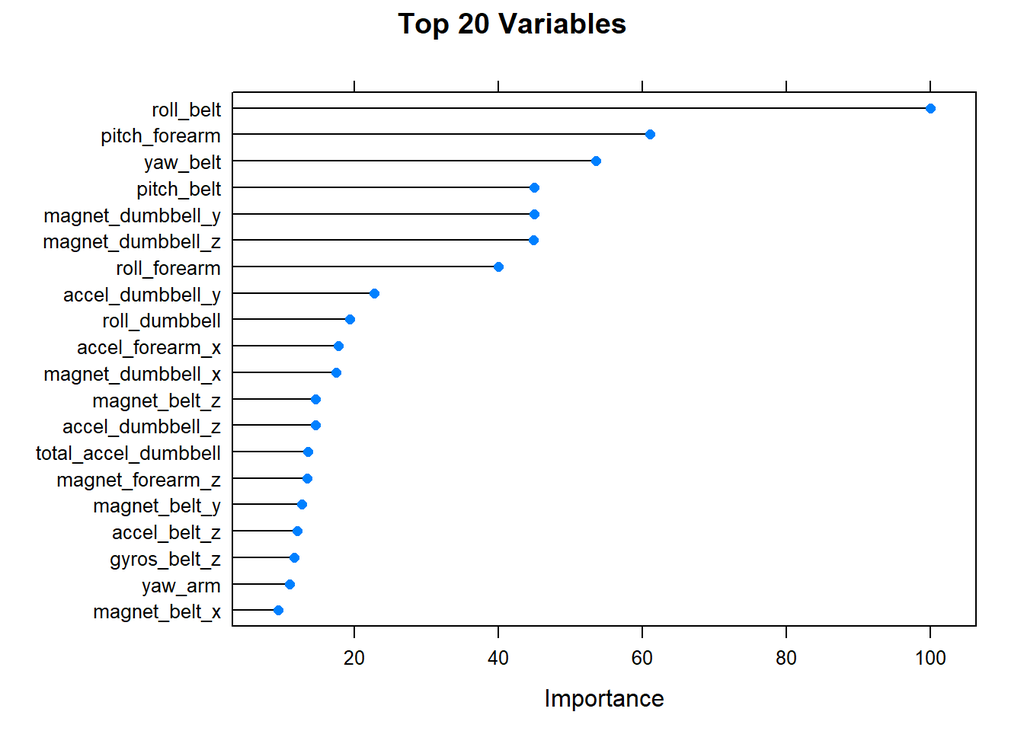

```r
varImportant <- varImp(mdRandomf)
plot(varImportant, main = "Top 20 Variables", top = 20)
```

Tree Visualization

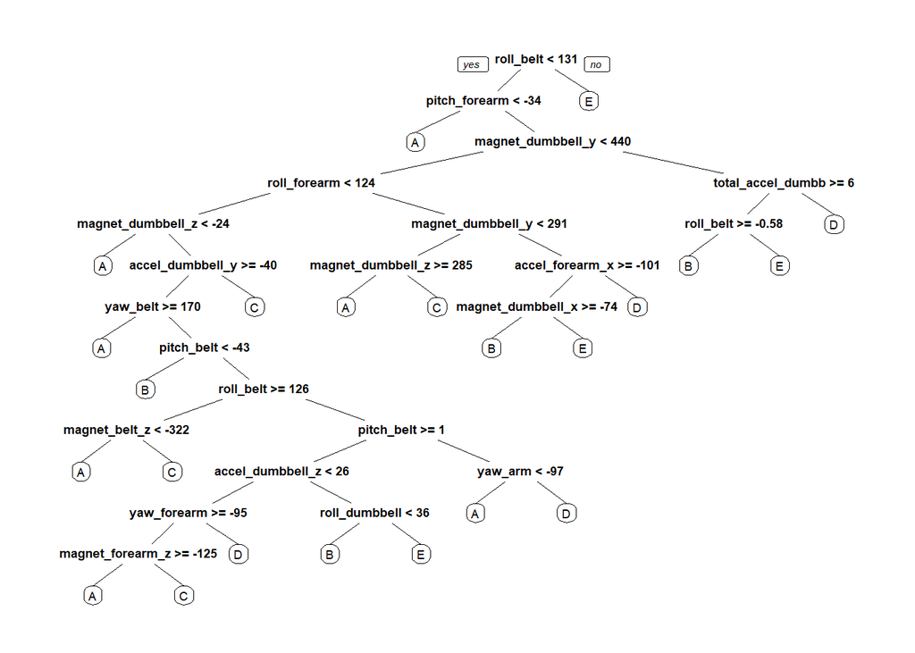

```r
treeModel <- rpart(classe ~ ., data=training, method="class")
prp(treeModel)
```

```r
Validation$classe <- factor(Validation$classe)
ac <- postResample(predictRandomf,Validation$classe)
ac
```

```
##  Accuracy     Kappa
## 0.9944943 0.9930351
```

working with the test suite

```r
subset(dstesteCleaned, select = -c(problem_id))
```

[output not shown]

[output cut: 216 more lines]

```r
dstesteCleaned = subset(dstesteCleaned, select = -c(problem_id))
result <- predict(predictRandomf, dstesteCleaned)
result
```

[output not shown]

Conclusion

The random forest model worked very well. The Confusion Matrix achieved 0.9945 accuracy